# Gov 50 Final Project

However, since oil producing regions appear to have significant effects on regions that traditionally are associated with less economic activity, I believe it is important in the next visualization to determine if high oil revenues impact lower GDP per capita countries more than more economically affluent countries. GDP may be a confounding variable within the effects oil has on a nation. This data will also be performed on all nations and will include their repeating values from 1945-1991 in order to take into account regime and polity score shifts.

Thus,

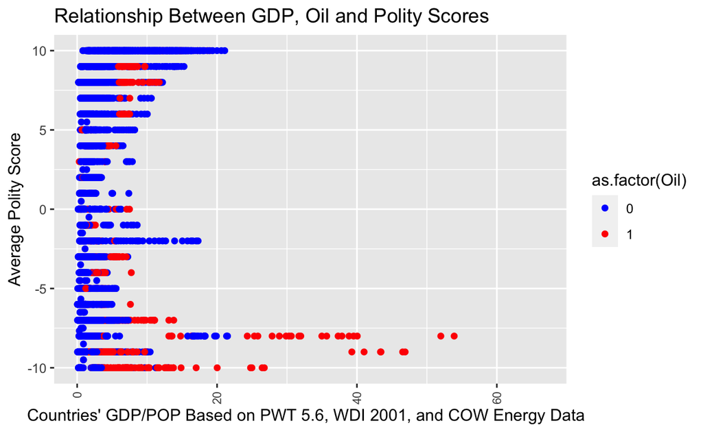

```r
##pop ~ population, in 1000s


plot2<- civilwar|>
  filter(year == 1945|1991)|>
     group_by(country, gdpen, Oil)|>
  summarize(average_polity = mean(polity2, na.rm = TRUE))|>
  ggplot(mapping = aes(y = average_polity, x = gdpen, color = as.factor(Oil))) + geom_point() + scale_color_manual(values = c("0" ="blue", "1"= "red"))+
  theme(axis.text.x = element_text(angle = 90, size=8, vjust = 0.5, hjust=1)) + labs(y = "Average Polity Score", x = "Countries' GDP/POP Based on PWT 5.6, WDI 2001, and COW Energy Data  ", title = "Relationship Between GDP, Oil and Polity Scores")


plot2
```

In contrast to what was believed earlier it seems that nations with both high GDP per capita and high oil production seem to have a correlation with lower average polity scores. Therefore, there may be confounding variables that have to do with regional location and how oil effects the polity scores. Thus, maybe nations with high production capacity from oil may be more effective in centralizing control of their government type away from the commons, and thus retaining lowered polity scores. Further, high GDP/pop may indicate that an extremely wealthy population may be okay with an authoritarian government because of high levels of disposable income.

```r
civilwar45to91<- civilwar|>
  filter(year == 1945|1991)


Regression <- lm(polity2 ~ Oil,
               data = civilwar45to91)

Regression
```

```
Call:
lm(formula = polity2 ~ Oil, data = civilwar45to91)

Coefficients:
(Intercept)          Oil
     0.1216      -4.1181
```

Conclusion: